# El efecto de la persepcion de la meritocracia sobre la aceptacion de la desigualdad de oportunidades

## 3.2 Graficos descriptivos de las variables de percepción de meritocracia

```r
pob_per[1:4] <-lapply(pob_per[1:4],factor, levels = 1:5)
likt <- likert(pob_per)
```

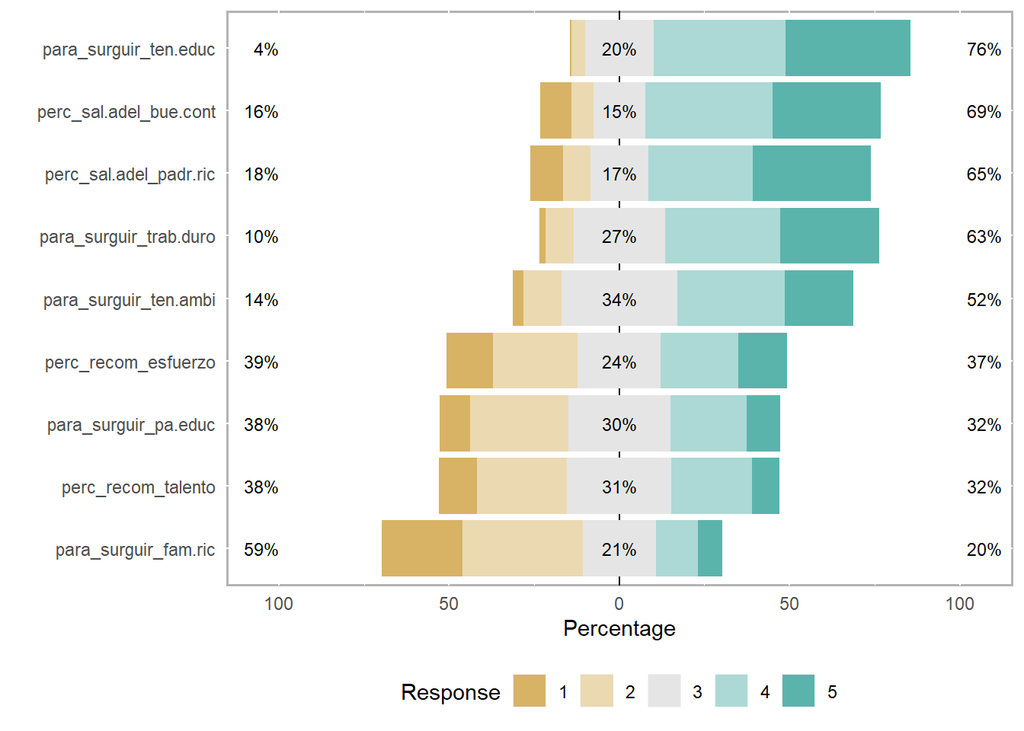

```r
plot(likt)
```

En primer lugar, la mayoría de las personas están de acuerdo con que para surgir es fundamental tener educación. La educación parece relacionarse con la idea de surgir o de elevarse en la escala social y por ello guardaría una relación con la noción de meritocracia, de hecho, en los análisis factoriales tiende a ser un factor junto a trabajar duro y tener ambición.

En segundo lugar, es interesante que las dos siguientes frases con mas acuerdo refieren a desigualdad de oportunidades, dando cuenta de una alta percepción de un contexto poco propicio para la meritocracia.

En último lugar, el hecho de que la frase con menor acuerdo sea “para surgir es necesario tener padres ricos” al mismo tiempo que hay un alto grado de acuerdo con que las personas con padres ricos logran salir adelante, sugiere que el término “para surgir” se relaciona más con ideales normativos, mientras que cuando se pregunta “En Chile las personas con padres ricos logran salir adelante” la gente lo interpreta más como percepción. Para evaluar este hipo tesis, hay que analizar la relación entre ambos modos de fraseo y las opiniones normativas

## 3.3 Graficos descriptivos de las variables de la visión normativa de la meritocracia

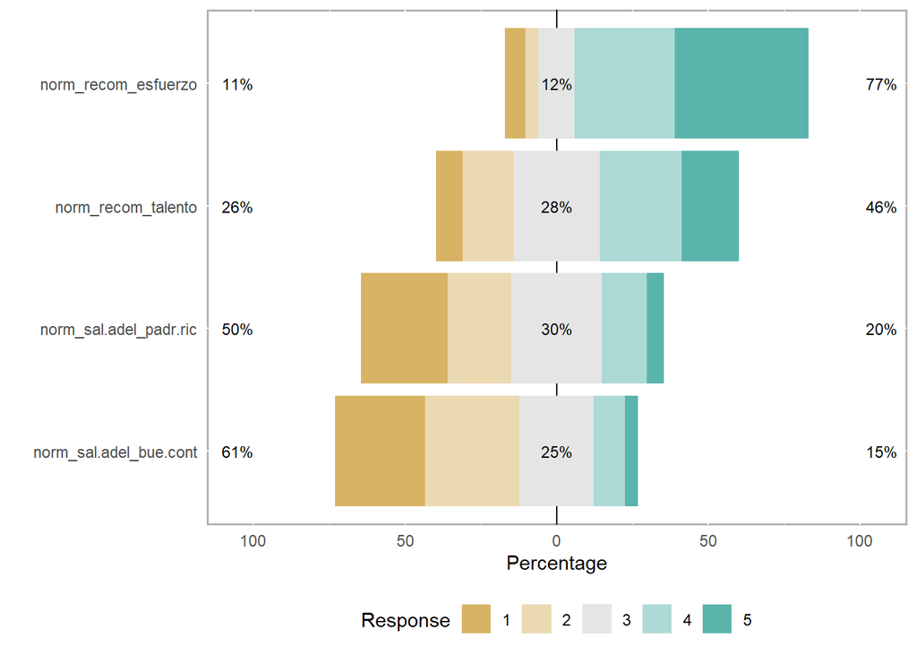

```r
pob_norm[,1:4] <-lapply(pob_norm[,1:4],factor, levels=1:5)
likt3 <- likert(pob_norm)
plot(likt3)
```

Existe un mayor acuerdo normativo con la redistribucion basada en componentes meritorios, es decir un mayor acuerdo con la meritocracia, que con la reproduccion de la desigualdades. Podemos decir por ello, que si bien no se consive una tan alta percepción de la meritocracia esta tiene un amplio apoyo en especial con le componente normativo del esfuerzo.

hay una muy menor cantidad de personas que estan de acuerdo con que las personas con padres ricos o con buenos contactos salgan adelante. Estas serian personas que normativamente estan de acuerdo con que existan desventajas.

# 4 Analisis de Correlaciones

## 4.1 Correlaciones de persepcion sobre la meritocracia

Correlaciones Policoricas

```r
pcor_mer <-polychoric(pob_per,smooth=TRUE,global=TRUE,polycor=FALSE, ML = FALSE,
       std.err=FALSE,weight=NULL,progress=TRUE,na.rm=TRUE, delete=TRUE)
```

```
## Converted non-numeric input to numeric
```

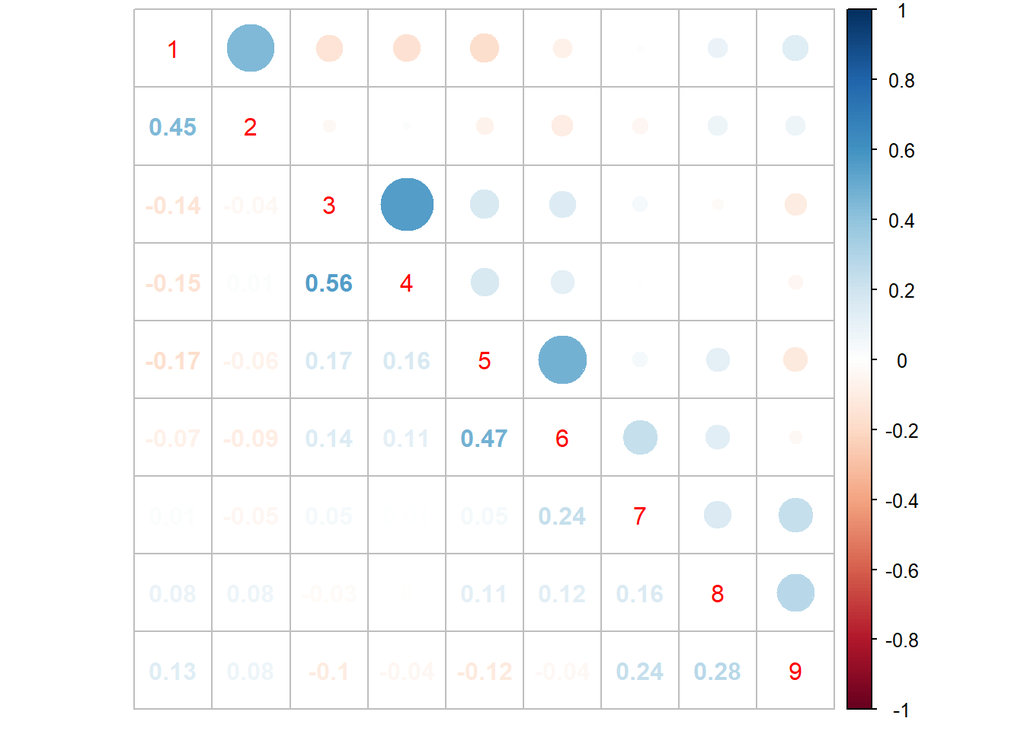

```r
corrplot.mixed(pcor_mer$rho,tl.pos = c("d"), diag = c("u"))
```

En funcion de estas relaciones policoricas podemos decir que ests variables no se relacionan todas entre si, siendo complejo considerarlas como distintas formas de medir meritocracia, más bien, tenemos pares de variables que se relacionan, y nos dan cuenta de algunas posibles dimenciones.

## 4.2 Correlaciones entre indicadores normativos de meritocracia

Correlaciones policoricas

```r
pcor_norm<-polychoric(pob_norm,smooth=TRUE,global=TRUE,polycor=FALSE, ML = FALSE,
       std.err=FALSE,weight=NULL,progress=TRUE,na.rm=TRUE, delete=TRUE)
```

```
## Converted non-numeric input to numeric
```

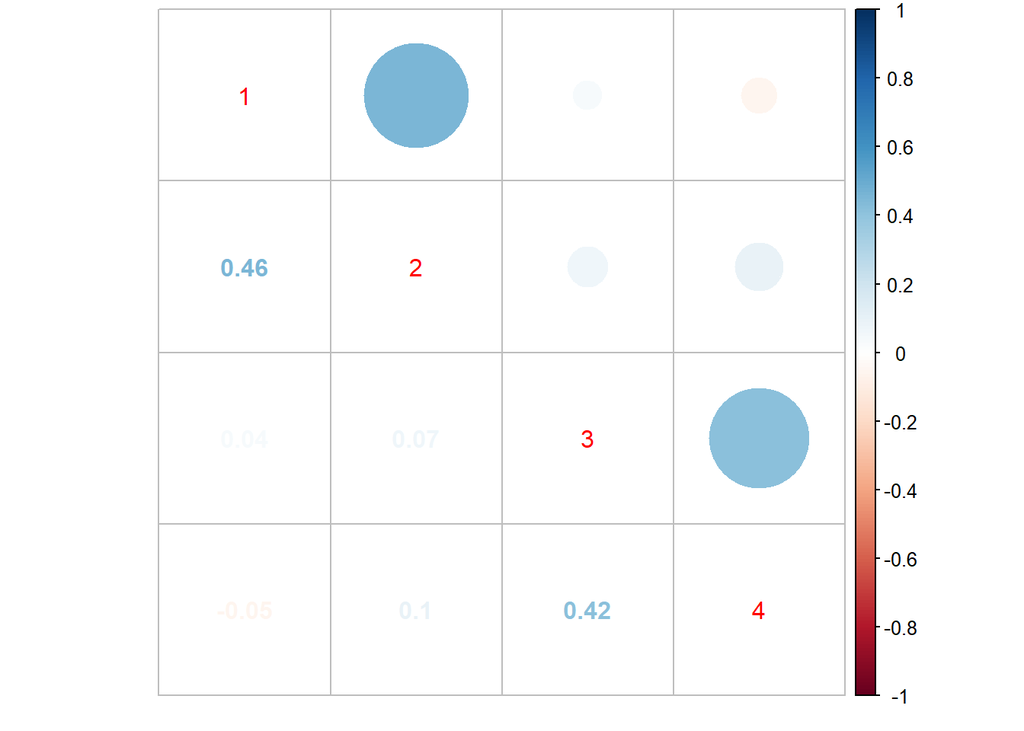

```r
corrplot.mixed(pcor_norm$rho,tl.pos = c("d"), diag = c("u"))
```

En funcion de estas correlaciones policoricas se puede preever que existiran dos factores en este conjunto de variables, dado que no existen correlaciones entre todas ellas que superen el .3, sino que solo se da dicha fuerza de relacion en pares que son coherentes entre si, en tanto aluden o a meritocracia o a la desigualdad de oportunidades.